# Cohort Analysis

Final Report

Philippe Lambot

September 7, 2019

$~$

$~$

$~$

## I. Introduction

### A. Data Source

Cohort analysis will be applied to data from the 10-million-row MovieLens dataset in order to gain further insights about user behavior.

In the MovieLens system, users can issue ratings about movies in order to receive movie recommendations. Among numerous useful references, let’s just mention the following ones:

```
https://grouplens.org/datasets/movielens/
https://movielens.org/
https://grouplens.org/
https://en.wikipedia.org/wiki/MovieLens
https://en.wikipedia.org/wiki/GroupLens_Research
```

$~$

In my Recommendation-System Project (please see the GitHub repository https://github.com/Dev-P-L/Recommendation-System), I have developed predictive analysis about ratings.

A model has been built up on the edx subset of data of 90% of data picked up at random from the 10-million-row dataset. The independent variable, i.e. ratings, has been “explained” by four predictors: time effect, genre effect, user effect and movie effect.

That model has been validated on the validation dataset (10% of the 10-million-row dataset). Each of the four predictors has showed predictive capability.

But interpreting time effect was not straightforward.

$~$

### B. Objective

In this study, time effect will be scanned thanks to cohort analysis in other to gain further insights. The following dimensions will be analyzed: - retention over user lifetime by cohort, - change in retention over product lifetime, - evolution of rating number by cohort, - evolution of rating average, - retention by genre, - retention by movie release year.

$~$

### C. Software Preferences: PostgeSQL, Excel, R Markdown, HTML and GitHub

Analysis will be conducted first in PostgreSQL with the IDE pgAdmin: data import, database management, data wrangling and basic results from cohort analysis. Hereunder, PostgreSQL will be simply referred to as “SQL”.

Cohort analysis will be further refined in Excel with pivot tables. Graphical visualization will also be created in Excel.

The final report will be produced in R Markdown with the IDE RStudio. Two formats will be provided: one in HTML and one in PDF.

Transferring files between SQL, Excel and R Markdown will be performed in CSV format for data and PNG format for graphs. CSV files will be created in Calc from LibreOffice because, on my system, Calc provides high operational convenience with decimal separator. PNG files will be created in MS Paint.

All files (71) are available in my GitHub repository https://github.com/Dev-P-L/Cohort-Analysis .

Readers are most welcome to run the 7 SQL scripts and the pivot tables. For readers interested, some pieces of advice are provided in Appendix I.

$~$

## II. Data Preparation

### A. Database Creation

After creating a database cohort-analysis in pgAdmin, the first SQL script can be run. It is called 02_database_management_and_data_wrangling_SQL_script and can be found in the GitHub repository https://github.com/Dev-P-L/Cohort-Analysis .

$~$

### B. Data Import

Hereunder, for simplicity reasons, files from the GitHub repository will no longer be referred to by their long name but only by their sequential number in the GitHub repository (01, 02, etc.).

In the table dataset, the field “genre” is comprised of composite genres such as “Action|Adventure|Sci-Fi|Thriller”. A few additional examples have been retrieved in a CSV file and are showcased in the following sample table.

$~$

| Table 1 - Illustrative Examples of Composite Genres |
| --- |

| Movie Id | Title | Composite Genre |
| --- | --- | --- |
| 231 | Dumb & Dumber (1994) | Comedy |
| 480 | Jurassic Park (1993) | Action\|Adventure\|Sci-Fi\|Thriller |
| 586 | Home Alone (1990) | Children\|Comedy |
| 151 | Rob Roy (1995) | Action\|Drama\|Romance\|War |
| 858 | Godfather, The (1972) | Crime\|Drama |

$~$

### C. Database Management and Data Wrangling

The SQL script (file 02 in the GitHub repository) then creates two additional tables, i.e. the table movies and the table ratings.

In the table movies, the primary key is movie_id. Data are the imported into the table movies with movie release years being extracted from the field title. Then the field genre is split into 19 basic genres (such as “drama”, “action”, etc.) on separate rows (see CSV copy in file 04). Splitting is performed with the regexp_split_to_table() function. Then the 19 basic genres are ranked in columns by using a pivot table in Excel and the result (file 06) is copied to the table movies.

The table ratings is comprised of the fields rating_id, user_id, movie_id, rating and rating_year. The primary key is a combination of rating_id and movie_id; movie_id is also a foreign key that references movie_id from the table movies, movie_id being the primary key in the table movies. Consequently, the table ratings is a referencing table and the table movies is the referenced table.

Data for rating_id, user_id, movie_id and rating are copied from the table dataset without any transformation. Data for rating_year come from the field rating_timestamp from the table dataset, using the instruction EXTRACT(year FROM to_timestamp(rating_timestamp)) AS rating_timestamp .

In a snapshot, in the database cohort-analysis, which has been managed in pgAdmin, there is a table dataset with all imported data, the table movies, which is a referenced table with primary key movie_id, and the table ratings, which is a referencing table whose primary key is a combination of rating_id and movie_id and whose foreign key is movie_id.

After this piece of database management, data import and data wrangling, let’s move to exploratory data analysis.

$~$

## III. Exploratory Data Analysis

Let’s do some data preparatory analysis to deliver preliminary insights and prepare cohort analysis. Three SQL queries will be run: one global query (file 08), one query by (basic) genre (file 16) and one by movie release year (file 20).

$~$

### A. Global Exploratory Analysis

The global query delivers per rating year

```
the number of active users,
the number of ratings,
the number of movies,
the number of ratings per active user
and the average rating.
```

$~$

Results can be found in CSV file 09. They are used in XLSX file 10 to process graphs. Graphs are available in PNG format in files 11 to 15. They are also inserted and commented upon here under.

$~$

#### 1. Number of Active Users per Rating Year

The first graph hereunder shows that the number of active users reached a high in 1996 with more than 16,000 users, before falling below 2,000 in 1998. Afterwards, it evolved between 4,700 and 9,300 per year. The year range is from 1996 to 2008. Years 1995 and 2009 have been discarded from the graph because the number of active users was exceptionally low during these years, as can be seen in the first tab from the XLSX file 10: there was only one active user in 1995 and 275 in 2009.

So, the number of active users varies rather hectically per year between 1996 and 1998 before stabilizing somewhat between 1999 and 2008. Would this go hand in hand with changes in retention? We will see that in section IV. Cohort Analysis.

$~$

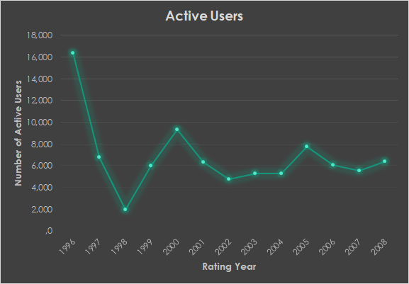

Graph 1

$~$

#### 2. Number of Ratings per Rating Year

Graph 2 shows how the number of ratings evolves per year. It shows some similarity with the first graph except for 1996, which is no longer predominant as it was in number of active users per year. How to explain levels after 1998: are they still due to the numerous users who joined in 1996 or to users who joined more recently?

$~$

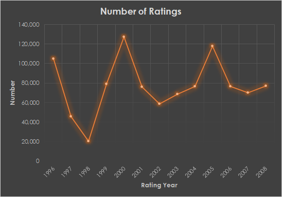

Graph 2

$~$

#### 3. Number of Rated Movies per Rating Year

Graph 3 is about the number of rated movies per year. There is a continued increase from 1996 to 2005 before the number of rated movies plateauing per year. Movies will be further split according to genre and release year, in preparatory analysis and cohort analysis.

$~$

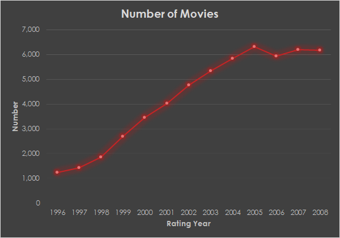

Graph 3

$~$

#### 4. Average Number of Ratings per Active User

What about the average number of ratings per active user? Graph 4 illustrates this. Contrary to the predominant number of active users in 1996, the average number of ratings per active user is relatively low in 1996, with little more than 6, and it remains below 7 in 1997, before rocketing above 10 in 1998. It still increases in 1999 and 2000 before remaining at 12 or more from 2001 to 2008.

Would the higher levels observed from 1999 onwards be, at least partially, linked to user retention increasing over product lifetime?

$~$

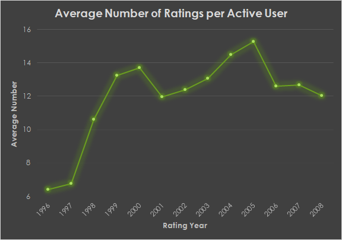

Graph 4

$~$

#### 5. Average Rating per Rating Year

The very concept of average rating is also decisive in this study. Indeed, understanding how users rate movies is essential to improve product, i.e. recommendations delivered to users on the basis of their own ratings. Graph 5 already sheds some light on rating evolution.

After some ups and downs from 1997 to 1999, there is a downward trend in average rating per year from 2000 to 2004, followed by partial recovery until 2008. Will that general development be shared by all user cohorts delimited by join year?

$~$

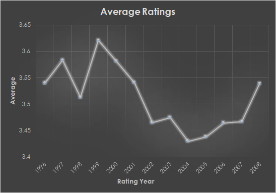

Graph 5

$~$

### B. Exploratory Analysis per Basic Genre

In this preparatory analysis, let’s move to a breakdown by basic genre. Ratings will be broken down by basic genre. The SQL query that delivers these results can be found in file 16 in the GitHub repository. Quantitative results are produced in file 17, are further processed in Excel (file 18) to create a graph (see PNG file 19).

Graph 6 illustrates the wide variation range of ratings by basic genre, from 899 ratings for IMAX movies to 434,071 ratings for drama movies. By the way, let’s notice that the total of rating numbers by basic genre is 2,595,771, which is far greater than the total of ratings, which is 999,999. Why? Because many movies had composite genres, i.e. genres regrouping several basic genres. Consequently, ratings for a lot of movies are counted several times. In spite of obvious redundancies, graph 6 gives a rough idea of distribution of ratings by basic genre.

Breakdown by basic genre will be taken on board in cohort analysis.

$~$

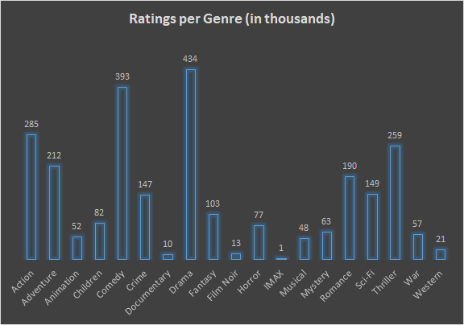

Graph 6

$~$

### C. Exploratory Analysis per Movie Release Year

Last step in preparatory analysis, data will be broken down by release year. The SQL query that is saved in file 20 will insulate movies released before 1990 in a CSV file (file 21). It will produce some statistics per rating year comparable with the statistics already produced for all movies together: number of active users, number of ratings, number of movies and number of ratings per active user. The number of active users per rating year is illustrated in an XLSX file (file 22) and in PNG format (file 23).

Graph 7 can be fruitfully compared with graph 1. Both give the number of active users per rating year, with graph 7 being limited to movies released before 1990 and graph 1 encompassing all movies irrespective of release year. In graph 1, we had a high for 1996, with the curve plunging after 1996; in 1996, there were more than 16,000 active users, in 1998, less than 2,000! In graph 7, there is no such pattern: after 1996, the curve dips a little but the highest point is no longer 1996, it is 2000; 1996 is at 3,550 active users, 2000 is at 7,496 active users! The difference is sensible.

$~$

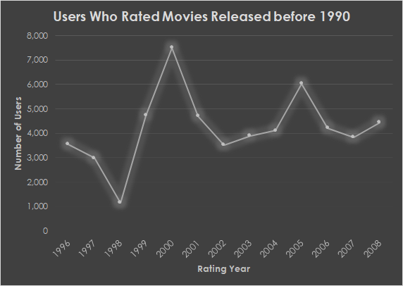

Graph 7

$~$

## IV. Cohort Analysis

### A. Global Cohort Analysis

Cohort analysis can now get started. In file 24, there is an SQL query that performs cohort analysis.

First, years 1995 and 2009 are discarded because there are relatively few data (see above).

Second, user cohorts are prepared by assigning a join year to each user.

Third, by join year and by rating year, the following series are computed:

```
- number of ratings,
- user retention (in numbers of users),
- the average number of ratings per active user
- and the average rating.
```

$~$

Fourth, by user cohort (i.e. by join year), the following series are calculated:

```
- the number of users in each cohort during the join year
- the number of ratings in each cohort during the join year.
```

$~$

This aims at enabling to compute

```
- user retention for each rating year in percentage of join year,
- rating number for each rating year in percentage of join year.
```

$~$

Fifth, now the final table can be built up, per cohort and rating year, with the following series:

```
- join year,
- rating year,
- the difference between rating year and join year,
- the user retention (in numbers of users),
- the number of users during the join year,
- the user retention in percent of the join year,
- the number of ratings,
- the number of ratings during the join year,
- the number of ratings in percent of the join year,
- the average number of ratings per active user
- and the average rating.
```

$~$

Results are saved in CSV format in file 25. They are further processed in XLSX with pivot tables and graphs (file 26). Results from pivot tables are separately saved in 6 files (files 27, 28, 30, 31, 33, 35); graphs are saved in 4 PNG files (29, 32, 34, 36).

$~$

#### 1. User Retention

Table 2 shows user retention by user cohort, i.e. by users’ join year.

$~$

| Table 2 - User Retention |
| --- |

|  | Join Year | Y 1 | Y 2 | Y 3 | Y 4 | Y 5 | Y 6 | Y 7 | Y 8 | Y 9 | Y 10 | Y 11 |
| --- | --- | --- | --- | --- | --- | --- | --- | --- | --- | --- | --- | --- |
| Cohort 1996 | 16,366 | 941 | 18 |  |  |  |  |  |  |  |  |  |
| Cohort 1997 | 5,847 | 211 | 72 | 61 | 49 | 36 | 36 | 32 | 33 | 25 | 14 | 16 |
| Cohort 1998 | 1,703 | 130 | 83 | 68 | 49 | 49 | 42 | 43 | 33 | 24 | 19 |  |
| Cohort 1999 | 5,761 | 1,400 | 673 | 527 | 461 | 373 | 301 | 211 | 168 | 134 |  |  |
| Cohort 2000 | 7,751 | 1,080 | 620 | 495 | 401 | 331 | 244 | 183 | 165 |  |  |  |
| Cohort 2001 | 4,460 | 578 | 372 | 278 | 211 | 154 | 128 | 94 |  |  |  |  |
| Cohort 2002 | 2,914 | 499 | 310 | 233 | 152 | 118 | 106 |  |  |  |  |  |
| Cohort 2003 | 3,347 | 640 | 352 | 248 | 174 | 157 |  |  |  |  |  |  |
| Cohort 2004 | 3,226 | 572 | 340 | 242 | 171 |  |  |  |  |  |  |  |
| Cohort 2005 | 5,659 | 817 | 505 | 353 |  |  |  |  |  |  |  |  |
| Cohort 2006 | 3,845 | 623 | 372 |  |  |  |  |  |  |  |  |  |
| Cohort 2007 | 3,358 | 583 |  |  |  |  |  |  |  |  |  |  |
| Cohort 2008 | 4,227 |  |  |  |  |  |  |  |  |  |  |  |

As evidenced by Table 2, retention over user lifetime drops dramatically from join year to first year and once again from first year to second year. Let’s remember that join year is for each user the year with their first rating. The next year is called “first year”, although it is the second one, because it is, for each cohort, it is the first year for which user retention can be calculated. For illustrative purposes, let’s consider Cohort 1996: in 1996, there are 16,366 active users; in 1997, there remain just 941 users.

This can usefully help explain ratings and their evolution. Nevertheless, other factors should be taken on board when explaining , such as the number of ratings per cohort and the average rating per cohort and per rating year. These additional factors will be analyzed later on.

$~$

#### 2. User Retention in Percentage of Join Year

In table 3, user retention will be computed in percentage of join year so that retention over user lifetime can be more easily compared between cohorts. We will be in a better position to perceive change in retention over product lifetime.

$~$

| Table 3 - User Retention in Percentage |
| --- |

|  | Join Year | Y 1 | Y 2 | Y 3 | Y 4 | Y 5 | Y 6 | Y 7 | Y 8 | Y 9 | Y 10 | Y 11 |
| --- | --- | --- | --- | --- | --- | --- | --- | --- | --- | --- | --- | --- |
| Cohort 1996 | 100 | 5.8 | 0.1 |  |  |  |  |  |  |  |  |  |
| Cohort 1997 | 100 | 3.6 | 1.2 | 1 | 0.8 | 0.6 | 0.6 | 0.6 | 0.6 | 0.4 | 0.2 | 0.3 |
| Cohort 1998 | 100 | 7.6 | 4.9 | 4 | 2.9 | 2.9 | 2.5 | 2.5 | 1.9 | 1.4 | 1.1 |  |
| Cohort 1999 | 100 | 24.3 | 11.7 | 9.2 | 8 | 6.5 | 5.2 | 3.7 | 2.9 | 2.3 |  |  |
| Cohort 2000 | 100 | 13.9 | 8 | 6.4 | 5.2 | 4.3 | 3.2 | 2.4 | 2.1 |  |  |  |
| Cohort 2001 | 100 | 13 | 8.3 | 6.2 | 4.7 | 3.5 | 2.9 | 2.1 |  |  |  |  |
| Cohort 2002 | 100 | 17.1 | 10.6 | 8 | 5.2 | 4.1 | 3.6 |  |  |  |  |  |
| Cohort 2003 | 100 | 19.1 | 10.5 | 7.4 | 5.2 | 4.7 |  |  |  |  |  |  |
| Cohort 2004 | 100 | 17.7 | 10.5 | 7.5 | 5.3 |  |  |  |  |  |  |  |
| Cohort 2005 | 100 | 14.4 | 8.9 | 6.2 |  |  |  |  |  |  |  |  |
| Cohort 2006 | 100 | 16.2 | 9.7 |  |  |  |  |  |  |  |  |  |
| Cohort 2007 | 100 | 17.4 |  |  |  |  |  |  |  |  |  |  |
| Cohort 2008 | 100 |  |  |  |  |  |  |  |  |  |  |  |

$~$

As shown in Table 3, retention over user lifetime improves from Cohort 1998 onwards. It reaches exceptional levels for Cohort 1999. After Cohort 1999, levels drop somewhat but remain higher than before Cohort 1999.

For instance, let’s consider first year retention. From levels below 6 % for Cohort 1996 and Cohort 1997, first year retention moves above 7 % for Cohort 1998 and then jumps to more than 24 % for Cohort 1999, before plateauing at 13 % or higher for subsequent cohorts.

Consequently, user retention over product lifetime shows a rather upward trend even if Cohort 1999’s exceptional levels are not fully maintained by subsequent cohorts.

This can be more easily perceived on Graph 8, where every other cohort is represented, starting with Cohort 1997.

$~$

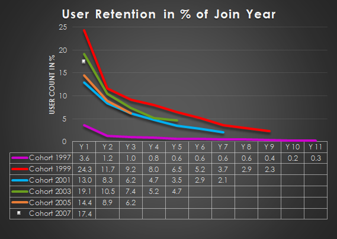

Graph 8

$~$

Graph 8 clearly illustrates how retention improves over product lifetime after Cohort 1997. For clarity reasons, not all cohorts are represented but halving the sample does not alter general conclusions; retention can be found for all cohorts in Table 2 and Table 3 and have already been commented upon.

While the magenta curve referencing Cohort 1997 remains relatively low, all other curves have a higher position. Cohort 1999 reaches exceptional levels. The second lowest curve, in blue, references Cohort 2001. Curves references Cohorts 2003, 2005 and 2007 are positioned higher than the blue curve of Cohort 2001.

$~$

#### 3. Number of Ratings by Cohort and by Rating Year

It’s high time we moved to the number of ratings. We will do that with Table 4, Table 5 and Graph 9. Table 4 presents the number of ratings by cohort and by rating year.

$~$

| Table 4 - Number of Ratings by Cohort |
| --- |

|  | Join Year | Y 1 | Y 2 | Y 3 | Y 4 | Y 5 | Y 6 | Y 7 | Y 8 | Y 9 | Y 10 | Y 11 |
| --- | --- | --- | --- | --- | --- | --- | --- | --- | --- | --- | --- | --- |
| Cohort 1996 | 104846 | 5013 | 23 |  |  |  |  |  |  |  |  |  |
| Cohort 1997 | 40833 | 1651 | 632 | 622 | 394 | 291 | 481 | 383 | 259 | 159 | 85 | 179 |
| Cohort 1998 | 18784 | 972 | 849 | 678 | 369 | 587 | 600 | 273 | 243 | 109 | 81 |  |
| Cohort 1999 | 77296 | 12665 | 4871 | 3685 | 4151 | 3735 | 2071 | 1108 | 1172 | 683 |  |  |
| Cohort 2000 | 113138 | 9079 | 4849 | 5227 | 4269 | 2616 | 1614 | 1274 | 1138 |  |  |  |
| Cohort 2001 | 60764 | 4978 | 4035 | 3183 | 1769 | 1093 | 698 | 606 |  |  |  |  |
| Cohort 2002 | 44278 | 5269 | 3635 | 1821 | 1024 | 853 | 659 |  |  |  |  |  |
| Cohort 2003 | 49006 | 7929 | 3074 | 2096 | 1210 | 1023 |  |  |  |  |  |  |
| Cohort 2004 | 53005 | 5260 | 2539 | 1575 | 1088 |  |  |  |  |  |  |  |
| Cohort 2005 | 100863 | 7103 | 3495 | 2437 |  |  |  |  |  |  |  |  |
| Cohort 2006 | 59439 | 5608 | 2750 |  |  |  |  |  |  |  |  |  |
| Cohort 2007 | 54078 | 5549 |  |  |  |  |  |  |  |  |  |  |
| Cohort 2008 | 60684 |  |  |  |  |  |  |  |  |  |  |  |

$~$

$~$

#### 4. Number of Ratings in Percentage

To better appreciate the churning rate, we will move to Table 5 where the number of ratings is expressed by cohort again but in percentage of the join year.

$~$

| Table 5 - Number of Ratings by Cohort in % of Join Year |
| --- |

|  | Join Year | Y 1 | Y 2 | Y 3 | Y 4 | Y 5 | Y 6 | Y 7 | Y 8 | Y 9 | Y 10 | Y 11 |
| --- | --- | --- | --- | --- | --- | --- | --- | --- | --- | --- | --- | --- |
| Cohort 1996 | 100 | 4.8 | 0 |  |  |  |  |  |  |  |  |  |
| Cohort 1997 | 100 | 4 | 1.6 | 1.5 | 1 | 0.7 | 1.2 | 0.9 | 0.6 | 0.4 | 0.2 | 0.4 |
| Cohort 1998 | 100 | 5.2 | 4.5 | 3.6 | 2 | 3.1 | 3.2 | 1.5 | 1.3 | 0.6 | 0.4 |  |
| Cohort 1999 | 100 | 16.4 | 6.3 | 4.8 | 5.4 | 4.8 | 2.7 | 1.4 | 1.5 | 0.9 |  |  |
| Cohort 2000 | 100 | 8 | 4.3 | 4.6 | 3.8 | 2.3 | 1.4 | 1.1 | 1 |  |  |  |
| Cohort 2001 | 100 | 8.2 | 6.6 | 5.2 | 2.9 | 1.8 | 1.2 | 1 |  |  |  |  |
| Cohort 2002 | 100 | 11.9 | 8.2 | 4.1 | 2.3 | 1.9 | 1.5 |  |  |  |  |  |
| Cohort 2003 | 100 | 16.2 | 6.3 | 4.3 | 2.5 | 2.1 |  |  |  |  |  |  |
| Cohort 2004 | 100 | 9.9 | 4.8 | 3 | 2.1 |  |  |  |  |  |  |  |
| Cohort 2005 | 100 | 7 | 3.5 | 2.4 |  |  |  |  |  |  |  |  |
| Cohort 2006 | 100 | 9.4 | 4.6 |  |  |  |  |  |  |  |  |  |
| Cohort 2007 | 100 | 10.3 |  |  |  |  |  |  |  |  |  |  |
| Cohort 2008 | 100 |  |  |  |  |  |  |  |  |  |  |  |

$~$

Graphical visualization can be found in Graph 9.

$~$

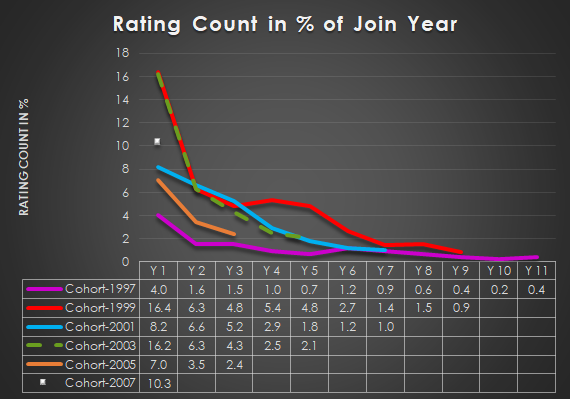

Graph 9

$~$

#### 5. Average Ratings by Cohort and by Rating Year

Let’s move to average ratings by cohort and by rating year. (Readers interested in the average number of ratings per active user can have a look at the table in file 33 and the graph in file 34.)

$~$

| Table 6 - Average Ratings by Cohort and by Rating Year |
| --- |

|  | Join Year | Y 1 | Y 2 | Y 3 | Y 4 | Y 5 | Y 6 | Y 7 | Y 8 | Y 9 | Y 10 | Y 11 |
| --- | --- | --- | --- | --- | --- | --- | --- | --- | --- | --- | --- | --- |
| Cohort 1996 | 3.54 | 3.61 | 3.74 |  |  |  |  |  |  |  |  |  |
| Cohort 1997 | 3.58 | 3.34 | 3.36 | 3.4 | 3.28 | 3.24 | 3.44 | 3.12 | 3.4 | 3.29 | 3.25 | 3.12 |
| Cohort 1998 | 3.53 | 3.51 | 3.36 | 3.34 | 3.4 | 3.34 | 3.39 | 3.42 | 3.32 | 3.45 | 3.36 |  |
| Cohort 1999 | 3.62 | 3.52 | 3.47 | 3.38 | 3.47 | 3.49 | 3.65 | 3.56 | 3.48 | 3.49 |  |  |
| Cohort 2000 | 3.59 | 3.46 | 3.4 | 3.43 | 3.48 | 3.54 | 3.44 | 3.48 | 3.49 |  |  |  |
| Cohort 2001 | 3.56 | 3.42 | 3.47 | 3.48 | 3.58 | 3.41 | 3.5 | 3.51 |  |  |  |  |
| Cohort 2002 | 3.48 | 3.43 | 3.39 | 3.46 | 3.4 | 3.42 | 3.43 |  |  |  |  |  |
| Cohort 2003 | 3.49 | 3.42 | 3.48 | 3.34 | 3.37 | 3.37 |  |  |  |  |  |  |
| Cohort 2004 | 3.42 | 3.41 | 3.41 | 3.52 | 3.45 |  |  |  |  |  |  |  |
| Cohort 2005 | 3.43 | 3.4 | 3.38 | 3.46 |  |  |  |  |  |  |  |  |
| Cohort 2006 | 3.48 | 3.33 | 3.43 |  |  |  |  |  |  |  |  |  |
| Cohort 2007 | 3.49 | 3.47 |  |  |  |  |  |  |  |  |  |  |
| Cohort 2008 | 3.56 |  |  |  |  |  |  |  |  |  |  |  |

$~$

Table 6 shows that for most cohorts the average rating is higher during the join year. During the join year, each cohort also benefits from the highest number of active users and by far; after the join year, churning is very impressive. Consequently, it is important to know the evolution of avarge rating by cohort and by rating year, especially if the challenge is predicting users’ ratings.

Decrease in average rating is the most noticeable for Cohort 1997, with average rating falling from 3.58 during join year to 3.34 during the first year after join year, and to 3.12 after 11 years.

For Cohort 2004 and Cohort 2005, there is first a slight drop then a slight increase.

Graph 10 hereunder illustrates evolution of average rating for some cohorts. Let’s notice once agin Cohort 1997.

$~$

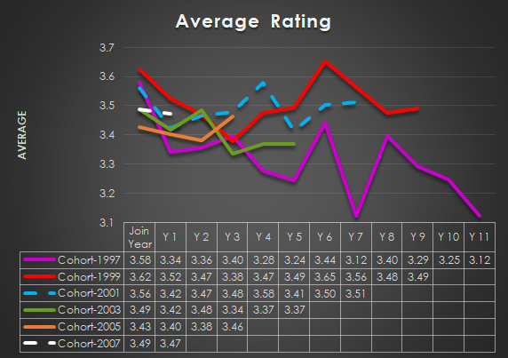

Graph 10

$~$

### B. Cohort Analysis by Basic Genre

Cohort analysis by basic genre is run in an SQL script saved in file 37.

Actually, that script is run to produce cohort analysis for the basic genre “drama” (in WHERE, instructions “m.drama = 1”). I have run that script for all 19 basic genres, simply changing the instraction “m.drama = 1”.

Raws results for all 19 basic genres are stored in 19 CSV files whose numbers are: 38, 40, 41, 42, 44, 46, 47, 48, 50, 51, 52, 53, 54, 56, 57, 59, 60, 61, 62. For illustrative purposes, six basic genres have been selected: action, children, comedy, drama, musical and romance. Piovt tables have been produced in Excel for these six basic genres in XLSX files whose numbers are: 39, 43, 45, 49, 55, 58. A summarizing graph has been produced in Excel for these six basic genres and is saved in PNG format under number 64.

$~$

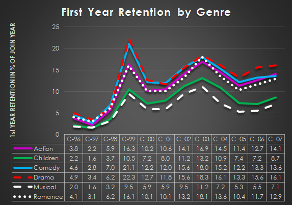

Graph 11

$~$

Actually, graph 11 shows first year retention by basic genre and by cohort.

Basic genre drama is generally in top position, usually closely followed by the basic genre comedy and sometimes even challenged by the basic genre comedy.

In last position, there is the basic genre musical, sometimes challenged, especially among the first cohorts, by the basic genre children.

In between, there is the basic genre action, closely followed by the basic genre romance and sometimes even challenged by the basic genre romance, especially among the first cohorts.

Breaking down by basic genre and by cohort seems promising to predict ratings and to better understand users’ behavioral patterns.

$~$

### C. Cohort Analysis by Movie Release Year

It is run in an SQL query saved in file 65.

Actually, movies released before 1990 have been insulated. User retention in percentage is presented in CSV file 66 and processed in Excel pivot table in file 67. A graph is presented in PNG file 68 and reproduced hereunder.

$~$

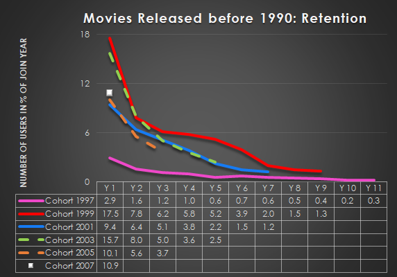

Graph 12

$~$

In comparison with Graph 8, which is relative to all movies, Graph 12 generally shows lower retention percentages that are calculated with respect to join year.